# Syntyvyysennuste 2023-2030

Antti J. Tanskanen, Elinkeinoelämän keskusliitto EK

1.3.2023

## Johdanto

Syntyneiden lasten määrä on Suomessa laskenut 61 000 lapsesta vuonna 2010 noin 44 700:ään vuonna 2022. Alkuvuoden 2018 luvuilla laskemalla vaikuttaa siltä että tämän vuoden syntyneden määrä jää ehkä 48 000:een ja hedelmällisyysluku 1,43:een alle vuoden 1973 pohjien. Laskeva trendi on jatkunut koko aikavälin 2010-2018, joten satunnaisvaihtelusta tuskin on kysymys. Osan syntyneiden lukumäärän laskusta selittää synnytysikäisten naisten lukumäärän pieneneminen, mutta ei läheskään kaikkea. Muiksi selityksiksi on tarjottu mm. työttömyyttä (Hiilamo, 2017) ja miesten heikkoa työsuhteeseen kiinnittymistä (Miettinen ja Jalovaara, 2015). Muissa maissa syntyvyyden laskun on arvioitu aiheutuvan mm. lapsikuolleisuuden vähenemisestä (Becker ja Barro, 1988), kaupungistumisesta (Martine et al., 2013) ja vanhuuseläkkeiden korkeammasta korvausasteesta (Boldrin et al., 2015). Sen lisäksi että työttömyys alentaisi syntyvyyttä, taloudellisten kriisien on myös havaittu lisänneen syntyvyyttä (Kohler ja Kohler, 2002).

Syntyneiden määrällä on viiveellä vaikutusta työikäisen väestön määrään, ja sitä kautta syntyvyyden laskulla on vaikutuksia mm. sosiaaliturvan rahoituksen kestävyyteen. Eläketurvakeskuksen laskelmien mukaan syntyvyyden lasku aiheuttaa työeläkemaksussa pitkällä aikavälillä useiden prosenttiyksiköiden nousupaineen (Tikanmäki, 2017). Myös Väestöntutkimuslaitos on analysoinut syitä syntyvyyden laskulle, mutta selkeätä syytä ei ole löytynyt (Rotkirch et al, 2017)

Tässä tutkimuksessa jatketaan aiemman harjoituksen mallilla ja kokeillaan miten hyvin ennuste toimii. Tämän lisäksi tutkimuksessa pyritään tarkastelemaan, onko sosiaalisen median aktiivikäytön lisääntymisellä kytkentää syntyvyyden laskuun.

## Aineisto

Tutkimuksessa käytetty aikasarja-aineisto on peräisin tilastokeskuksen StatFin-tietokannasta ja Human Mortality Databasesta. Aineisto koostuu vuosien 1989-2021 datasta. Väestörakenteesta (Tilastokeskus) mukana on syntyneidet lukumäärät, kokonaishedelmällisyysluvut, synnyttäjien keski-ikä ja naisten lukumäärät 5-vuotisikäryhmittäin. Mukana ovat myös avioituvuus 10-vuotisikäluokittain (Tilastokeskus).

Kaupungistumista kuvaa sisemmässä kaupungissa, ulommassa kaupungissa ja kehyskaupungissa asuvien osuudet väestöstä (Tilastokeskus)-

Mukaan on otettu myös sosiaalisen median aktiivikäyttäjien osuus Tilastokeskuksen Viestintä- ja tietotekniikan käyttö-tutkimuksesta (“Seuraa jotain yhteisöpalvelua yleensä jatkuvasti kirjautuneena tai useasti päivässä”).

Aineiston perusteella ei voi tehdä kausaalisia päätelmiä, ainostaan assosiatiivisuutta koskevia. Tämä tietenkin rajoittaa tulkintamahdollisuuksia.

Tarkoituksena on avoimen, toistettavan tutkimuksen hengessä näyttää täsmällisesti mitä on tehty. Tästä syystä alkuperäinen aineisto (myös tämä työkirja koodeineen, Rmd-muotoisena; data Rdata-muodossa) on kokonaisuudessaan saatavissa osoitteesta https://github.com/ajtanskanen/Syntyvyyden-tekij-t

```
## # A tibble: 42 × 82
##     ...1 vuosi syntyneita hedelmallisyysluku tfr_lin tyollisyysaste_miehet_15_24
##    <dbl> <dbl>      <dbl>              <dbl>   <dbl>                       <dbl>
##  1     1  1989      63348               1.71    1.71                        53.7
##  2     2  1990      65549               1.79    1.79                        52
##  3     3  1991      65395               1.8     1.8                         43
##  4     4  1992      66731               1.85    1.85                        33.9
##  5     5  1993      64826               1.81    1.81                        29.3
##  6     6  1994      65231               1.85    1.85                        27.3
##  7     7  1995      63067               1.81    1.81                        29.9
##  8     8  1996      60723               1.76    1.76                        30.2
##  9     9  1997      59329               1.75    1.75                        34
## 10    10  1998      57108               1.71    1.71                        36.1
## # ℹ 32 more rows
## # ℹ 76 more variables: tyollisyysaste_naiset_15_24 <dbl>,
## #   naisten_lkm_15_19 <dbl>, naisten_lkm_20_24 <dbl>, naisten_lkm_25_29 <dbl>,
## #   naisten_lkm_30_34 <dbl>, naisten_lkm_35_39 <dbl>, naisten_lkm_40_45 <dbl>,
## #   naisten_lkm_45_49 <dbl>, naisten_lkm_15_49 <dbl>, naisten_lkm_24_39 <dbl>,
## #   pienituloisuus_0_17 <dbl>, pienituloisuus_18_24 <dbl>,
## #   pienituloisuus_25_34 <dbl>, pienituloisuus_35_49 <dbl>, …
```

# Hedelmällisyysluvun muutoksia selittävä malli

Synnytysikäisten naisten lukumäärää pystytään lyhyellä aikavälillä ennustamaan melko hyvin, eikä siihen vaikuta juurikaan muut tekijät, kuten vaikkapa työllisyys tai taloudellinen tilanne. Jos jokin vaikuttaa syntyvyyteen, vaikutuksen pitäisi näkyä hedelmällisyysluvussa.

Yritetään sitten selittää hedelmällisyysluvun muutoksia käyttäen faktoreina kokoelmaa erilaisia tekijöitä ikäluokka- ja sukupuolikohtaisia avioituvuuksia ja pienituloisuusosuusasteita (60% mediaanitulosta); synnyttäjien keski-ikää, alle 1-vuotiaiden kuolleisuutta, sekä sisäkaupungissa, ulkokaupungissa ja kehyskaupungissa asuvien osuutta väestöstä. Lisäksi mukana on 25-34- ja 35-44 -vuotiaiden somen aktiivikäyttäjien osuus väestöstä.

```
##                               P(B != 0 | Y) model 1 model 2 model 3
## Intercept                             1.000   1.000   1.000   1.000
## lapsikuolleisuus                      0.125   0.000   0.000   0.000
## synnyttajien_keskiika                 0.187   0.000   0.000   0.000
## avioituvuus_naiset_25_29_lag1         0.138   0.000   0.000   0.000
## avioituvuus_naiset_30_34_lag1         0.731   1.000   0.000   1.000
## kehyskaupunki                         0.493   0.000   1.000   1.000
## sisempikaupunki                       0.951   1.000   1.000   1.000
## ulompikaupunki                        0.237   0.000   0.000   0.000
## some_25_34_lag1                       0.486   0.000   1.000   1.000
## some_35_44_lag1                       0.143   0.000   0.000   0.000
## dummy2021                             0.984   1.000   1.000   1.000
## BF                                       NA   1.000   0.846   0.519
## PostProbs                                NA   0.159   0.134   0.082
## R2                                       NA   0.963   0.970   0.974
## dim                                      NA   4.000   5.000   6.000
## logmarg                                  NA  39.731  39.564  39.076
```

Regressiokertoimet todennäköisimmässä mallissa ovat

```
##
##  Marginal Posterior Summaries of Coefficients:
##
##  Using  HPM
##
##  Based on the top  1 models
##                                post mean   post SD     post p(B != 0)
## Intercept                       1.7200000   0.0053001   1.0000000
## lapsikuolleisuus                0.0000000   0.0000000   0.1252898
## synnyttajien_keskiika           0.0000000   0.0000000   0.1866255
## avioituvuus_naiset_25_29_lag1   0.0000000   0.0000000   0.1384284
## avioituvuus_naiset_30_34_lag1   0.0096529   0.0006003   0.7311302
## kehyskaupunki                   0.0000000   0.0000000   0.4929656
## sisempikaupunki                -0.0812669   0.0038910   0.9510557
## ulompikaupunki                  0.0000000   0.0000000   0.2366320
## some_25_34_lag1                 0.0000000   0.0000000   0.4860013
## some_35_44_lag1                 0.0000000   0.0000000   0.1427086
## dummy2021                       0.1326026   0.0341585   0.9836437
```

Aggregaattikertoimet kaikissa mallissa todennäköisyyksillä painotettuna ovat

```
##
##  Marginal Posterior Summaries of Coefficients:
##
##  Using  BMA
##
##  Based on the top  1024 models
##                                post mean   post SD     post p(B != 0)
## Intercept                       1.720e+00   5.094e-03   1.000e+00
## lapsikuolleisuus               -2.301e+00   9.668e+00   1.253e-01
## synnyttajien_keskiika          -2.265e-02   6.699e-02   1.866e-01
## avioituvuus_naiset_25_29_lag1  -1.339e-05   1.712e-03   1.384e-01
## avioituvuus_naiset_30_34_lag1   5.560e-03   4.067e-03   7.311e-01
## kehyskaupunki                   1.095e-01   1.337e-01   4.930e-01
## sisempikaupunki                -9.134e-02   2.974e-02   9.511e-01
## ulompikaupunki                  1.625e-02   3.754e-02   2.366e-01
## some_25_34_lag1                -1.244e-03   1.526e-03   4.860e-01
## some_35_44_lag1                -8.776e-05   6.760e-04   1.427e-01
## dummy2021                       1.598e-01   4.832e-02   9.836e-01
```

Tarkastetaan vielä, millaisia residuaaleja jää selittämättä mallilla

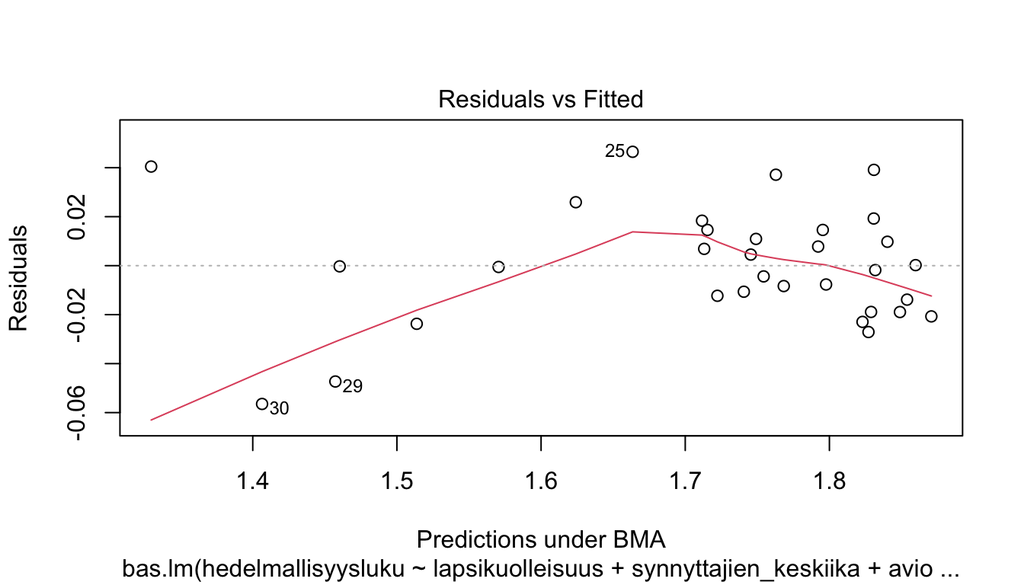

Ja lopuksi verrataan mallin sovitetta

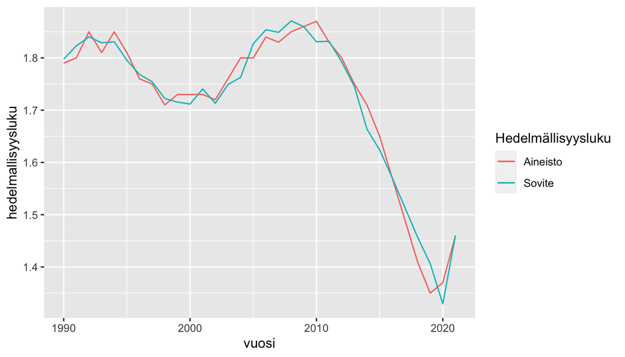

# Ennuste

Pyritään sitten arvioimaan miten hedelmällisyysluku kehittyy, mikäli 10 viime vuoden trendi jatkuisi näiden neljän tekijän osalta. Jatketaan trendiä lineaarisesti avioituvuudelle, kaupungistumiselle ja aktiivisten somen käyttäjien osuudelle. Muut tekijät pidetään vakiona.

```
##                               P(B != 0 | Y) model 1 model 2 model 3 model 4
## Intercept                             1.000   1.000   1.000   1.000   1.000
## lapsikuolleisuus                      0.125   0.000   0.000   0.000   0.000
## synnyttajien_keskiika                 0.187   0.000   0.000   0.000   0.000
## avioituvuus_naiset_25_29_lag1         0.138   0.000   0.000   0.000   0.000
## avioituvuus_naiset_30_34_lag1         0.731   1.000   0.000   1.000   1.000
## kehyskaupunki                         0.493   0.000   1.000   1.000   1.000
## sisempikaupunki                       0.951   1.000   1.000   1.000   1.000
## ulompikaupunki                        0.237   0.000   0.000   0.000   0.000
## some_25_34_lag1                       0.486   0.000   1.000   1.000   0.000
## some_35_44_lag1                       0.143   0.000   0.000   0.000   0.000
## dummy2021                             0.984   1.000   1.000   1.000   1.000
## BF                                       NA   1.000   0.846   0.519   0.269
## PostProbs                                NA   0.159   0.134   0.082   0.043
## R2                                       NA   0.963   0.970   0.974   0.967
## dim                                      NA   4.000   5.000   6.000   5.000
## logmarg                                  NA  39.731  39.564  39.076  38.416
##                               model 5 model 6 model 7 model 8 model 9 model 10
## Intercept                       1.000   1.000   1.000   1.000   1.000    1.000
## lapsikuolleisuus                0.000   0.000   0.000   1.000   0.000    0.000
## synnyttajien_keskiika           0.000   0.000   0.000   0.000   0.000    0.000
## avioituvuus_naiset_25_29_lag1   0.000   0.000   1.000   0.000   0.000    0.000
## avioituvuus_naiset_30_34_lag1   1.000   1.000   1.000   1.000   0.000    1.000
## kehyskaupunki                   0.000   0.000   0.000   0.000   1.000    1.000
## sisempikaupunki                 1.000   1.000   1.000   1.000   1.000    1.000
## ulompikaupunki                  1.000   1.000   0.000   0.000   1.000    0.000
## some_25_34_lag1                 0.000   1.000   0.000   0.000   1.000    0.000
## some_35_44_lag1                 0.000   0.000   0.000   0.000   0.000    1.000
## dummy2021                       1.000   1.000   1.000   1.000   1.000    1.000
## BF                              0.246   0.158   0.148   0.134   0.126    0.117
## PostProbs                       0.039   0.025   0.024   0.021   0.020    0.019
## R2                              0.967   0.972   0.965   0.965   0.971    0.971
## dim                             5.000   6.000   5.000   5.000   6.000    6.000
## logmarg                        38.330  37.883  37.822  37.723  37.662   37.589
```

Regressiokertoimet todennäköisimmässä mallissa ovat

```
##
##  Marginal Posterior Summaries of Coefficients:
##
##  Using  HPM
##
##  Based on the top  1 models
##                                post mean   post SD     post p(B != 0)
## Intercept                       1.7200000   0.0053001   1.0000000
## lapsikuolleisuus                0.0000000   0.0000000   0.1252898
## synnyttajien_keskiika           0.0000000   0.0000000   0.1866255
## avioituvuus_naiset_25_29_lag1   0.0000000   0.0000000   0.1384284
## avioituvuus_naiset_30_34_lag1   0.0096529   0.0006003   0.7311302
## kehyskaupunki                   0.0000000   0.0000000   0.4929656
## sisempikaupunki                -0.0812669   0.0038910   0.9510557
## ulompikaupunki                  0.0000000   0.0000000   0.2366320
## some_25_34_lag1                 0.0000000   0.0000000   0.4860013
## some_35_44_lag1                 0.0000000   0.0000000   0.1427086
## dummy2021                       0.1326026   0.0341585   0.9836437
```

```
##
##  Marginal Posterior Summaries of Coefficients:
##
##  Using  BMA
##
##  Based on the top  1024 models
##                                post mean   post SD     post p(B != 0)
## Intercept                       1.720e+00   5.094e-03   1.000e+00
## lapsikuolleisuus               -2.301e+00   9.668e+00   1.253e-01
## synnyttajien_keskiika          -2.265e-02   6.699e-02   1.866e-01
## avioituvuus_naiset_25_29_lag1  -1.339e-05   1.712e-03   1.384e-01
## avioituvuus_naiset_30_34_lag1   5.560e-03   4.067e-03   7.311e-01
## kehyskaupunki                   1.095e-01   1.337e-01   4.930e-01
## sisempikaupunki                -9.134e-02   2.974e-02   9.511e-01
## ulompikaupunki                  1.625e-02   3.754e-02   2.366e-01
## some_25_34_lag1                -1.244e-03   1.526e-03   4.860e-01
## some_35_44_lag1                -8.776e-05   6.760e-04   1.427e-01
## dummy2021                       1.598e-01   4.832e-02   9.836e-01
```

```
##
##  Marginal Posterior Summaries of Coefficients:
##
##  Using  MPM
##
##  Based on the top  1 models
##                                post mean   post SD     post p(B != 0)
## Intercept                       1.7200000   0.0053001   1.0000000
## lapsikuolleisuus                0.0000000   0.0000000   0.0000000
## synnyttajien_keskiika           0.0000000   0.0000000   0.0000000
## avioituvuus_naiset_25_29_lag1   0.0000000   0.0000000   0.0000000
## avioituvuus_naiset_30_34_lag1   0.0096529   0.0006003   1.0000000
## kehyskaupunki                   0.0000000   0.0000000   0.0000000
## sisempikaupunki                -0.0812669   0.0038910   1.0000000
## ulompikaupunki                  0.0000000   0.0000000   0.0000000
## some_25_34_lag1                 0.0000000   0.0000000   0.0000000
## some_35_44_lag1                 0.0000000   0.0000000   0.0000000
## dummy2021                       0.1326026   0.0341585   1.0000000
```

```
##  [1] 1.803765 1.821141 1.828706 1.810927 1.834250 1.807535 1.775837 1.778485
##  [9] 1.720724 1.719916 1.706558 1.749188 1.703415 1.746853 1.747818 1.837590
## [17] 1.863653 1.837590 1.870006 1.871128 1.839834 1.840395 1.791322 1.730260
## [25] 1.642171 1.604681 1.564856 1.519240 1.468797 1.400979 1.340883 1.461498
## [33] 1.290390 1.258643 1.226895 1.195148 1.163400 1.131652 1.099905 1.068157
## [41] 1.036410
## attr(,"model")
## [1]  0  4  6 10
## attr(,"best")
## [1] 714
## attr(,"estimator")
## [1] "HPM"
```

```
## [1] 1.349113
```

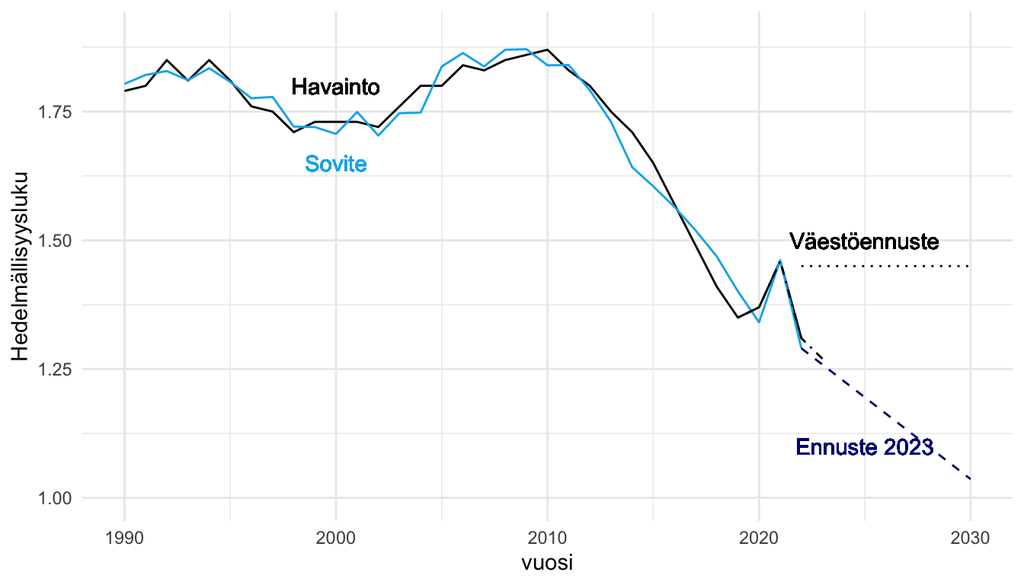

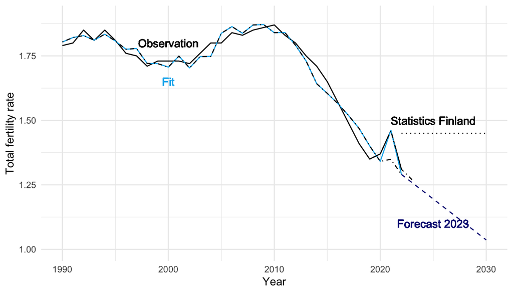

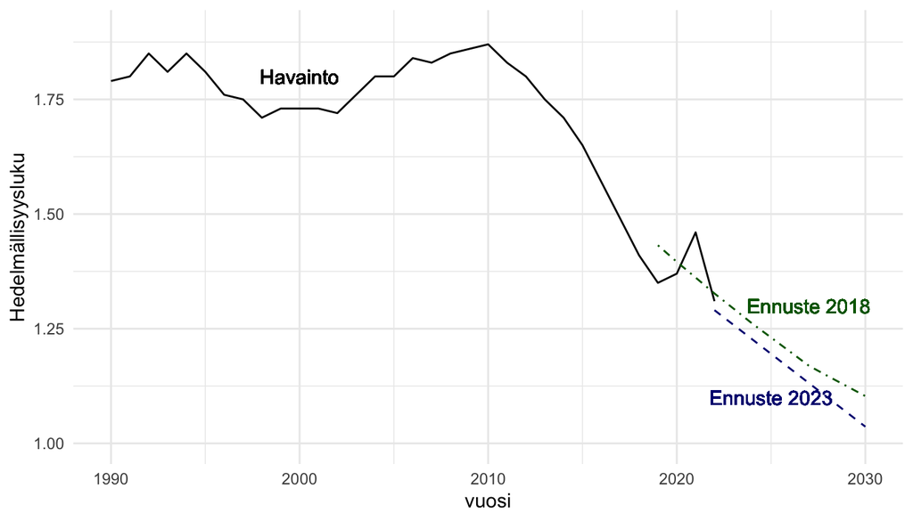

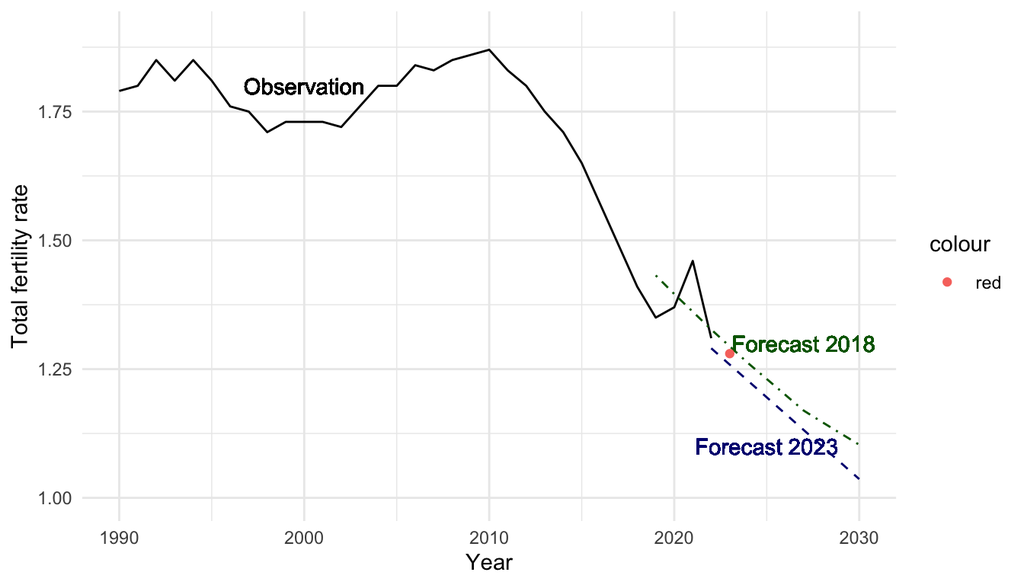

```
##  [1] 49.6 51.4 50.5 49.5 53.6 54.2 52.6 55.4 51.1 52.7 53.0 59.1 55.2 59.7 59.8
## [16] 69.1 71.8 69.1 73.3 75.1 72.7 73.6 70.2 66.4 59.8 57.6 56.0 53.8 51.1 46.6
## [31] 42.9 42.5
```

```
##  [1] 32.5 32.5 32.3 32.4 32.6 33.0 33.2 33.5 33.7 33.9 34.1 34.3 34.4 34.4 34.4
## [16] 34.4 34.4 34.4 34.5 34.7 34.8 34.9 35.1 35.4 35.7 35.9 36.2 36.5 36.8 37.1
## [31] 37.4 37.5
```

Miten aineiston arviointi onnistui?

Mallin ennuste 2018 kerätyn datan (aineisto 2017 ja aiemmin) perusteella vuodelle 2022 oli 1,326819, kun toteuma oli 1,31. Ennuste oli melko hyvä jälkeenpäin arvioituna. Lineaarisesti kokonaishedelmällisyysluvun trendiä jatkamalla tulos olisi ollut 1,09 (1v trendimuutos) tai 1,19 (5v trendimuutos), joka olisi ollut merkittävästi huonompi tulos.

## Syntyvyyden laskun syyt

Vaikka tällä tutkimuksella ei pääse kiinni syntyvyyden laskun kausaalisiin syihin, näkyy tuloksista selvästi, että syntyvyyden laskua ajaa kaksi erilaista tekijää: hedelmällisyysluvun lasku ja synnytysikäisten naisten lukumäärän lasku. Vaikeampaa on yrittää selittää, mistä hedelmällisyysluvun lasku johtuu.

Regressiokerrointen mukaan sisemmässä kaupungissa asuvien osuuden kasvu alentaa syntyvyyttä ja lykkää lasten hankintaa. Toisaalta ulommassa kaupungissa (samoin kuin maaseudulla) asuvien osuuden kasvu näyttäisi lisäävän syntyvyyttä ja vähentävän lastenhankinnan lykkäämistä. Tulokset ovat intuition mukaisia, koska sisemmissä kaupungeissa erityisesti lapsiperheille sopivien asuntojen hintataso on korkea, kun taas kauempana kaupunkien keskustoista hintataso on alempi. Kaupungistuminen ei siis välttämättä alenna syntyvyyttä, vaikka sisäkaupungeissa asuvien osuuden kasvu näyttää alentavan syntyvyyttä.

Suurin osa lapsiperheistä on edelleen avioperheitä. Avioituvuus erityisesti 30-34-vuotiailla kytkeytyy selvästi syntyneiden lasten määrään. Ainakin aiemmin on argumentoitu, että verrattuna avoliittoihin, avioliitoissa syntyy enemmän lapsia. Kyse voi olla myös valinnasta, mutta osaltaan avioituvuuden aleneminen kertoo asenne- tai preferenssimuutoksesta.

Tässä tutkimuksessa aineisto koostui pienestä määrästä havaintoja. Tästä syystä tuloksiin on syytä suhtautua varovaisuudella, vaikka usealle löydetylle tekijälle on selkeä selitys. Sovellettaessa faktorimallia eteenpäin, näkyy selvästi että hedelmällisyysluku jatkaa jyrkkää laskuaan. Faktorimallin tulokset ovat melko herkkiä sille, mitä selittäviä muuttujia valitaan mukaan, erityisesti eri muuttujien keskinäiset painoarvot muuttuvat helposti.

Verrattuna Tilastokeskuksen väestöennusteeseen 2018 ovat tämän mallin ennusteet selvästi synkempiä syntyvyyden osalta.

# Viittaukset

Becker, G.S., Barro, R.J., Reformulation of the economic theory of fertility, The quarterly journal of economics, 1988

Boldrin, M., De Nardi, M., Jones, L.E. Fertility and social security, Journal of Demographic Economics 81, 261-299, https://doi.org/10.1017/dem.2014.14, 2015

Doepke, M., Child mortality and fertility decline: Does the Barro-Becker model fit the facts?

Hiilamo, H. T., Fertility Response to Economic Recessions in Finland 1991–2015 Finnish Yearbook of Population Research 52, 15-28 . DOI: 10.23979/fypr.65254, 2017

Kohler, H.-P., Kohler, I., Fertility Decline in Russia in the Early and Mid 1990s: The Role of Economic Uncertainty and Labour Market Crises, European Journal of Population 18, 233-262, https://doi.org/10.1023/A:1019701812709, 2002.

Martine, G., Alves, J.E., Cavenaghi, S., Urbanization and fertility decline: Cashing in on structural change, IIED Working paper, 2013

Miettinen, A., Miksi syntyvyys laskee? Suomalaisten lastensaantiin liittyviä toiveita ja odotuksia. Perhebarometri 2015. Väestöliitto, 2015.

Miettinen, A., Jalovaara, M. Stable employment – more babies? Life stage and educational differences in the effects of labour market attachment on first birth among Finnish men and women. Working Papers on Social and Economic Issues 15/2016, Turku Center for Welfare Research, 2016

Rotkirch, A., Tammisalo, K., Miettinen, A., Berg, V. Miksi vanhemmuutta lykätään? Perhebarometri, 2017.

Tanskanen, A.J. Sosiaalisen median aktiivikäyttö ja syntyvyys. https://ajtanskanen.github.io/posts/2018/11/Sosiaalisen-median-aktiivik%C3%A4ytt%C3%B6-ja-syntyvyys/, 2018

Tikanmäki, H., Huomisen aikuiset syntyvät nyt, Eläketurvakeskuksen blogi https://www.etk.fi/blogit/huomisen-aikuiset-syntyvat-nyt/, 2017

# Liite: Aika-sarjojen kuvaukset

*syntyneet* Syntyneiden lasten lukumäärä. Lähde: Tilastokeskus

*hedelmallisyysluku* “Kokonaishedelmällisyysluku saadaan laskemalla yhteen yhdelle ikävuodelle lasketut hedelmällisyysluvut. Näin saatu luku tarkoittaa laskennallista lasten määrää, jonka nainen synnyttää kyseisen vuoden hedelmällisyyden pysyessä voimassa naisen koko hedelmällisen kauden edellyttäen, ettei hän kuole ennen tämän kauden päättymistä.” Lähde: Tilastokeskus, Väestörakenne-tilasto

*lapsikuolleisuus* Alle 1-vuotiaana kuolleiden osuus elävänä syntyneistä. Lähde: Human mortality database

*tyollisyysaste_miehet_15_24_lag1, tyollisyysaste_naiset_25_34_lag1, tyollisyysaste_miehet_35_44_lag1, tyollisyysaste_naiset_15_24_lag1, tyollisyysaste_miehet_25_34_lag1, tyollisyysaste_naiset_45_44_lag1* Yhden vuoden viivästetty 10-vuotisikäluokittainen työllisyysaste miehille ja naisille. Lähde: Tilastokeskus

*synnyttajien_keskiika* Laskettu synnyttäneiden äitien ikien keskiarvona. Lähde: Tilastokeskus

*avioituvuus_naiset_25_29, avioituvuus_naiset_30_34* Naisten solmittujen avioliittojen lukumäärä suhteessa samanikäisten naisten lukumäärään. Lähde: Tilastokeskus

*sisempikaupunki, ulompikaupunki, kehykaupunki* Sisempi kaupunkialue on kaupunkien tiivis yhtenäinen tehokkaasti rakennettu alue. Ulompi kaupunkialue on sisemmän kaupunkialueen reunasta yhtenäisesti jatkuvan taajamarakenteen reunalle ulottuva kaupunkimaisen tehokkuuden alue. Kaupungin kehysalue on kaupunkiin välittömästi kytkeytyvä osa kaupungin ja maaseudun välivyöhykkeestä. Lähde: TK

*naisten_lkm_15_19, naisten_lkm_20_24, naisten_lkm_25_29, naisten_lkm_30_34,naisten_lkm_35_39, naisten_lkm_40_45, naisten_lkm_45_49* Synnytysikäiset naiset 5-vuotisikäluokittain Lähde: Tilastokeskus

*miesten_tyottomyysaste_15_24_lag1, naisten_tyottomyysaste_15_24_lag1, miesten_tyottomyysaste_25_34_lag1, naisten_tyottomyysaste_25_34_lag1, miesten_tyottomyysaste_35_44_lag1, naisten_tyottomyysaste_35_44_lag1* Yhden vuoden viivästetty 10-vuotisikäluokittainen työttömyysaste miehille ja naisille Lähde: Tilastokeskus

*some_25_34, some_35_44* “Seuraa jotain yhteisöpalvelua yleensä jatkuvasti kirjautuneena tai useasti päivässä”. Tilastokeskuksen Viestintä- ja tietotekniikan käyttö-tutkimuksesta 10-vuotisikäluokat. Aineisto 2012-2021. Tilastoa jatkettu taaksepäin suhteuttamalla 2012 tieto Internetin käyttäjien lukumäärän muutoksella Lähde: Tilastokeskus